# Analysis of terrorist activities around the world in 1970 - 2017 years

### This is my analysis of data set of global terrorism below.

Data downloaded from: [Global Terrorism Database](https://www.kaggle.com/START-UMD/gtd)

The database GTD is an open-source database including information on terrorist attacks around the world from 1970 through 2017. The next lines contain accurate data on carried out terrorist attack, such as: date, location (country, region, city, the exact geographical coordinates), number of killed and wounded, name of the terrorist group and its method of attack.

### Context

Before I opened this data, I hadn't really realized that terrorist attacks are not isolated incidents which may occur once every few years!!

The purpose of my analysis is to show you that terrorism is a serious global problem. I used Python programming language together with special libraries (numpy, pandas, matplotlib) to explore the most interesting data. Don't be afraid :) - I won't overwhelm you by an enourmous amount of boring numbers and statistics. I also put some data visualization into my analysis.

### Importing and preparing data for futher analysis

```python
import pandas as pd
import numpy as np
import matplotlib.pyplot as plt
import seaborn as sns

data = pd.read_csv('globalterrorismdb_0718dist.csv', encoding='ISO-8859-1')

data.rename(columns={'iyear':'Year','imonth':'Month','iday':'Day','country_txt':'Country','region_txt':'Region','city':'City','attacktype1_txt':'AttackType','target1':'Target','nkill':'Killed','nwound':'Wounded','summary':'Summary','gname':'Terrorist_group','targtype1_txt':'Target_type','weaptype1_txt':'Weapon_type','motive':'Motive'},inplace=True)

data = data[['Year','Month','Day','Country','Region','City','AttackType','Killed','Wounded','Target','Summary','Terrorist_group','Target_type','Weapon_type','Motive']]
data['Casualties'] = data['Killed'] + data['Wounded']
data.head(10)
```

|  | Year | Month | Day | Country | Region | City | AttackType | Killed | Wounded | Target | Summary | Terrorist_group | Target_type | Weapon_type | Motive | Casualties |
| --- | --- | --- | --- | --- | --- | --- | --- | --- | --- | --- | --- | --- | --- | --- | --- | --- |
| 0 | 1970 | 7 | 2 | Dominican Republic | Central America & Caribbean | Santo Domingo | Assassination | 1.0 | 0.0 | Julio Guzman | NaN | MANO-D | Private Citizens & Property | Unknown | NaN | 1.0 |
| 1 | 1970 | 0 | 0 | Mexico | North America | Mexico city | Hostage Taking (Kidnapping) | 0.0 | 0.0 | Nadine Chaval, daughter | NaN | 23rd of September Communist League | Government (Diplomatic) | Unknown | NaN | 0.0 |
| 2 | 1970 | 1 | 0 | Philippines | Southeast Asia | Unknown | Assassination | 1.0 | 0.0 | Employee | NaN | Unknown | Journalists & Media | Unknown | NaN | 1.0 |
| 3 | 1970 | 1 | 0 | Greece | Western Europe | Athens | Bombing/Explosion | NaN | NaN | U.S. Embassy | NaN | Unknown | Government (Diplomatic) | Explosives | NaN | NaN |
| 4 | 1970 | 1 | 0 | Japan | East Asia | Fukouka | Facility/Infrastructure Attack | NaN | NaN | U.S. Consulate | NaN | Unknown | Government (Diplomatic) | Incendiary | NaN | NaN |
| 5 | 1970 | 1 | 1 | United States | North America | Cairo | Armed Assault | 0.0 | 0.0 | Cairo Police Headquarters | 1/1/1970: Unknown African American assailants ... | Black Nationalists | Police | Firearms | To protest the Cairo Illinois Police Deparment | 0.0 |
| 6 | 1970 | 1 | 2 | Uruguay | South America | Montevideo | Assassination | 0.0 | 0.0 | Juan Maria de Lucah/Chief of Directorate of in... | NaN | Tupamaros (Uruguay) | Police | Firearms | NaN | 0.0 |
| 7 | 1970 | 1 | 2 | United States | North America | Oakland | Bombing/Explosion | 0.0 | 0.0 | Edes Substation | 1/2/1970: Unknown perpetrators detonated explo... | Unknown | Utilities | Explosives | NaN | 0.0 |
| 8 | 1970 | 1 | 2 | United States | North America | Madison | Facility/Infrastructure Attack | 0.0 | 0.0 | R.O.T.C. offices at University of Wisconsin, M... | 1/2/1970: Karl Armstrong, a member of the New ... | New Year's Gang | Military | Incendiary | To protest the War in Vietnam and the draft | 0.0 |
| 9 | 1970 | 1 | 3 | United States | North America | Madison | Facility/Infrastructure Attack | 0.0 | 0.0 | Selective Service Headquarters in Madison Wisc... | 1/3/1970: Karl Armstrong, a member of the New ... | New Year's Gang | Government (General) | Incendiary | To protest the War in Vietnam and the draft | 0.0 |

### Basic questions to analyse the data set

#### 1. Which countries have had the most terrorist attacks since 1970 year?

```python
series = data['Country']
#choosing number of countries to print
n = 5

value = series.value_counts().index[:n]
print("Countries with the highest terrorist activities: ")
for x in value:
    print(x)
```

```
Countries with the highest terrorist activities:
Iraq
Pakistan
Afghanistan
India
Colombia
```

Graphically:

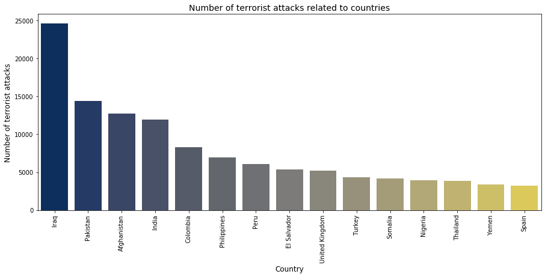

```python
plt.subplots(figsize=(15,6))
sns.countplot('Country',data=data, palette='cividis', order=data['Country'].value_counts().index[:15])
plt.xticks(rotation=90)
plt.xlabel('Country', fontsize=12)
plt.ylabel('Number of terrorist attacks', fontsize=12)
plt.title('Number of terrorist attacks related to countries', fontsize=14)
plt.show()
```

#### 2. Which regions in the world are the most common targets of terrorist attacks?

```python
series = data['Region']
#choosing number of regions to print
n = 5

value = series.value_counts().index[:n]
print("Regions with the highest terrorist activities: ")
for x in value:
    print(x)
```

```
Regions with the highest terrorist activities:
Middle East & North Africa
South Asia
South America
Sub-Saharan Africa
Western Europe
```

#### 3. How many people were killed as a result of terrorist attacks in the world since 1970?

```python
series = data['Killed']
print('Number of killed as a result of terrorist attacks:')
print(series.sum())
```

```
Number of killed as a result of terrorist attacks:
411868.0
```

#### 4. And how many since 2000?

```python
series = data[data['Year'] >= 2000]
killed = series['Killed']
print('Number of killed as a result of terrorist attacks since 2000 year:')
print(killed.sum())
```

```
Number of killed as a result of terrorist attacks since 2000 year:
271464.0
```

#### 5. And let's check how many people were killed in 2017 year around the world?

```python
series = data[data['Year'] == 2017]
killed = series['Killed']
print('Number of killed as a result of terrorist attacks in 2017 year:')
print(killed.sum())
```

```
Number of killed as a result of terrorist attacks in 2017 year:
26445.0
```

#### 6. And how many in the United States in 2001 year?

(also comparison of the number of killed with wounded there)

```python
series = data[(data['Year'] == 2001) & (data['Country'] == 'United States')]
print("United States in 2017")

killed = series['Killed']
print("Killed: " + str(killed.sum()))

wounded = series['Wounded']
print("Wounded: " + str(wounded.sum()))
```

[output not shown]

#### 7. Was there any terrorist attack in Poland?

```python
series = data[data['Country'] == 'Poland']
series = series['Country']
value = series.count()
if value:
    print("There were " + str(value) + " terrorist attacks in Poland.")
else:
    print("There was not any terrorist attack in Poland.")
```

```
There were 39 terrorist attacks in Poland.
```

### Let's move on to more interesting and more complex analyses :)

The first information appearing after dramatic events, such as a terrorist attack are **questions about people.** So let's pose a question:

**where were the most casualties as a result of terrorist attacks around the world?**

```
               Casualties
Country
Iraq             202982.0
Afghanistan       80213.0
Pakistan          64427.0
India             47108.0
Sri Lanka         29792.0
United States     24469.0
Colombia          23767.0
Philippines       22361.0
Nigeria           21728.0
Syria             21614.0
Algeria           19296.0
Somalia           16720.0
Turkey            16694.0
Yemen             16288.0
Peru              16246.0
```

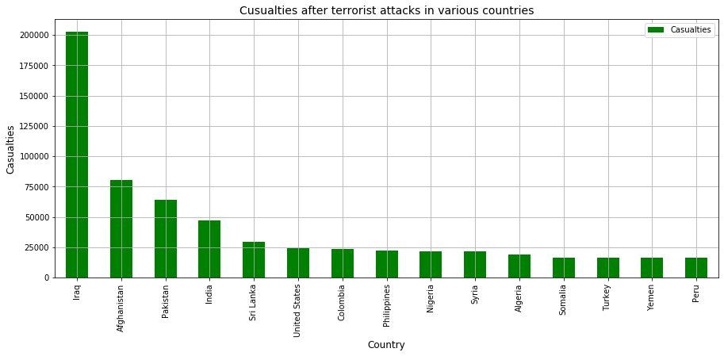

```python
series = data.groupby('Country')['Casualties'].sum()
series = pd.DataFrame(series)
series = series.sort_values(by=['Casualties'], ascending=False)
series = series[:15]
print(series)

fig = plt.figure()
series.plot.bar(figsize=(15,6), color = 'g')
plt.xlabel('Country', fontsize=12)
plt.ylabel('Casualties', fontsize=12)
plt.title('Cusualties after terrorist attacks in various countries', fontsize=14)
plt.xticks(rotation=90)
plt.grid(True)
plt.show()
```

**Comparison of the number of killed in various regions:**

```python
result = data.groupby('Region')['Killed'].sum()
result = pd.DataFrame(result)
result = result.sort_values(by=['Killed'], ascending=False)
print(result)
```

```
                               Killed
Region
Middle East & North Africa   137642.0
South Asia                   101319.0
Sub-Saharan Africa            78386.0
South America                 28849.0
Central America & Caribbean   28708.0
Southeast Asia                15637.0
Eastern Europe                 7415.0
Western Europe                 6694.0
North America                  4916.0
East Asia                      1152.0
Central Asia                   1000.0
Australasia & Oceania           150.0
```

The resulting data is shown graphically below:

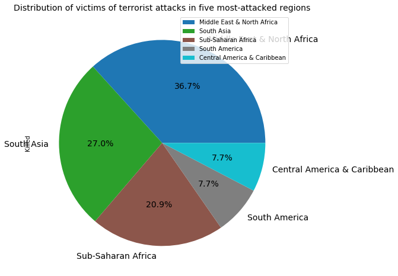

```python
result = result[:5]
result.plot(kind='pie', subplots=True, figsize=(8, 8), fontsize=14, autopct = '%1.1f%%', colormap = 'tab10')
plt.title('Distribution of victims of terrorist attacks in five most-attacked regions', fontsize=14)
plt.show()
```

**Comparison of the number of killed and wounded in the most attacked countries**

Data was sorted: first according to the highest number of killed and then the highest number of wounded.

```
              Killed   Wounded
Country
Iraq         78589.0  134690.0
Afghanistan  39384.0   44277.0
Pakistan     23822.0   42038.0
Nigeria      22682.0   10239.0
India        19341.0   28980.0
Sri Lanka    15530.0   15561.0
Syria        15229.0   14109.0
Colombia     14698.0   10328.0
Peru         12771.0    4078.0
El Salvador  12053.0    5062.0
                Killed   Wounded
Country
Iraq           78589.0  134690.0
Afghanistan    39384.0   44277.0
Pakistan       23822.0   42038.0
India          19341.0   28980.0
United States   3771.0   20702.0
Sri Lanka      15530.0   15561.0
Syria          15229.0   14109.0
Philippines     9559.0   13367.0
Lebanon         4061.0   10904.0
Colombia       14698.0   10328.0
```

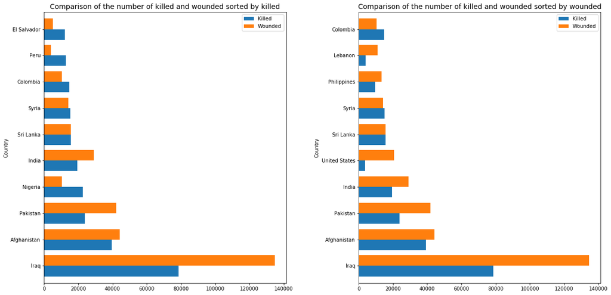

```python
killed = data.groupby('Country')['Killed'].sum()
killed = pd.DataFrame(killed)
#print(killed)

wounded = data.groupby('Country')['Wounded'].sum()
wounded = pd.DataFrame(wounded)
#print(wounded)

merge = pd.merge(killed, wounded, on='Country')
merge1 = merge.sort_values(by=['Killed'], ascending=False)
merge1 = merge1[:10]
print(merge1)
merge2 = merge.sort_values(by=['Wounded'], ascending=False)
merge2 = merge2[:10]
print(merge2)

fig = plt.figure()
fig, a =  plt.subplots(1,2, figsize=(20,10))
merge1.plot.barh(width=0.8, ax = a[0])
merge2.plot.barh(width=0.8, ax = a[1])
a[0].set_title('Comparison of the number of killed and wounded sorted by killed', fontsize=14)
a[1].set_title('Comparison of the number of killed and wounded sorted by wounded', fontsize=14)
plt.subplots_adjust(hspace=0.3, wspace=0.3)
plt.show()
```

### Subsequent analysis will directly involve detailed information on terrorist attacks

At the beginning, it was analyzed how the number of terrorist attacks are distributed in individual regions of the world.

In short: **where do the terrorist activities most often occur?**

The distribution is visually shown on two charts (used two diffrent libraries: matplotlib and seaborn to visualise the data):

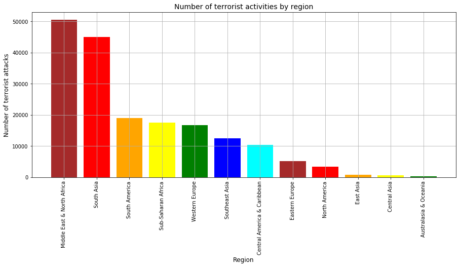

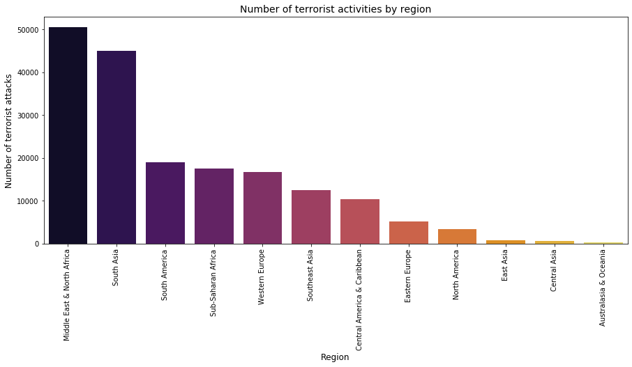

```python
#matplotlib
x = data['Region'].value_counts().index
y = data['Region'].value_counts().values

fig = plt.figure(figsize=(15,6))
plt.xlabel('Region', fontsize=12)
plt.ylabel('Number of terrorist attacks', fontsize=12)
plt.title('Number of terrorist activities by region', fontsize=14)
plt.xticks(rotation=90)
plt.bar(x, y, color=['brown', 'red', 'orange', 'yellow', 'green', 'blue', 'cyan'])
plt.grid(True)
plt.show()

#seaborn
plt.subplots(figsize=(15,6))
sns.countplot('Region',data=data,order=data['Region'].value_counts().index, palette='inferno')
plt.xticks(rotation=90)
plt.xlabel('Region', fontsize=12)
plt.ylabel('Number of terrorist attacks', fontsize=12)
plt.title('Number of terrorist activities by region', fontsize=14)
plt.show()
```

And now look at how these terrorist attacks in different regions were spread over several years:

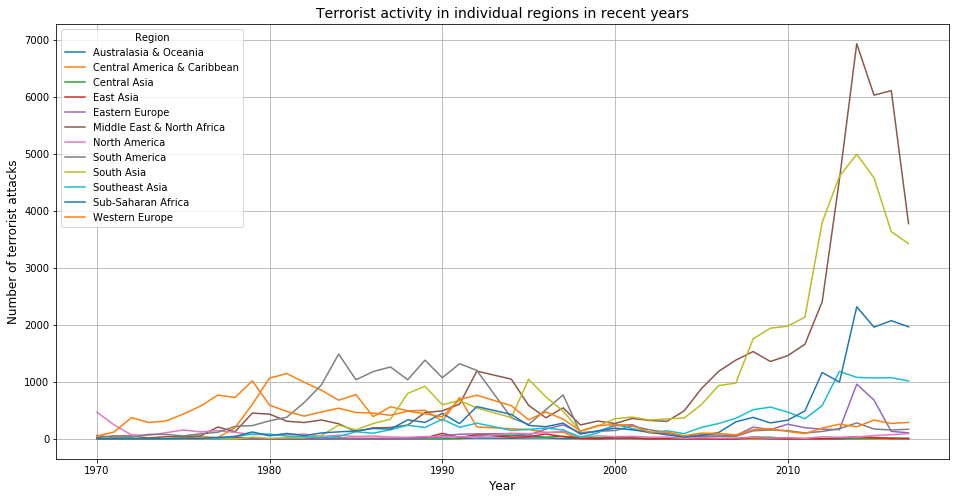

```python
fig = plt.figure()
result = pd.crosstab(data.Year,data.Region)
result.plot()
fig=plt.gcf()
fig.set_size_inches(16,8)
plt.xlabel('Year', fontsize=12)
plt.ylabel('Number of terrorist attacks', fontsize=12)
plt.title('Terrorist activity in individual regions in recent years', fontsize=14)
plt.grid(True)
plt.show()
```

#### Overall! The distribution of the amount of all attacks in the world over years is as follows:

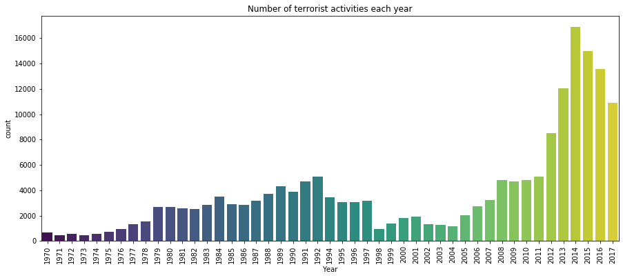

```
Adjusted this chart by adding a trend line
and a colormap to the bars: warmer color = more terrorist attacks.
```

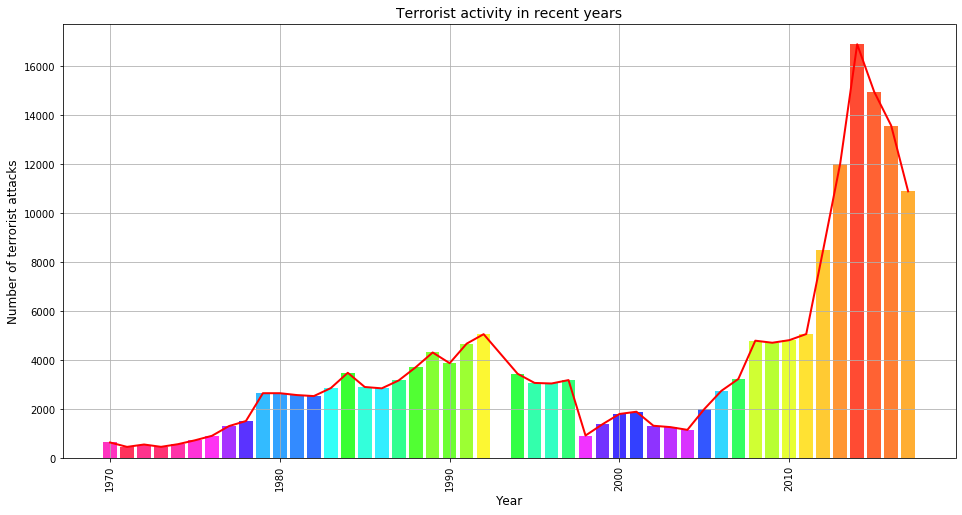

```
And if you prefer the numbers:
Year
1970      651
1971      471
1972      568
1973      473
1974      581
1975      740
1976      923
1977     1319
1978     1526
1979     2662
1980     2662
1981     2586
1982     2544
```

[output cut: 35 more lines]

```python
fig = plt.figure()
plt.subplots(figsize=(15,6))
sns.countplot('Year',data=data,palette='viridis')
plt.xticks(rotation=90)
plt.title('Number of terrorist activities each year')
plt.show()

print("Adjusted this chart by adding a trend line")
print("and a colormap to the bars: warmer color = more terrorist attacks.")
x = data['Year'].value_counts().index
y = data['Year'].value_counts().values
result = data.groupby('Year')['Year'].count()

fig = plt.figure()
plt.plot(result, color = 'r', linewidth = 2.0)
plt.bar(x, y, align='center', alpha=0.8, color = sns.color_palette('hsv', len(x)))
fig.set_size_inches(16,8)
plt.xlabel('Year', fontsize=12)
plt.ylabel('Number of terrorist attacks', fontsize=12)
plt.title('Terrorist activity in recent years', fontsize=14)
plt.xticks(rotation=90)
plt.grid(True)
plt.show()

print("And if you prefer the numbers: ")
trend = data.groupby('Year')['Year'].count()
print(trend)
```

**Time for little statistics 🙃!!**

Tried to calculate the average number of terrorist attacks per year, taking into account the years 1970 - 1999 and above 2000:

```python
series = data[data['Year'] < 2000]
y = series['Year'].value_counts()
#print(y)
print("The average number of terrorist attacks per year (below 2000 year)")
y.to_numpy()
print(np.mean(y))

series = data[data['Year'] >= 2000]
y = series['Year'].value_counts()
#print(y)
print("The average number of terrorist attacks per year (since 2000 year)")
y.to_numpy()
print(np.mean(y))
```

```
The average number of terrorist attacks per year (below 2000 year)
2408.137931034483
The average number of terrorist attacks per year (since 2000 year)
6214.166666666667
```

`Note: the average number of terrorist attacks per year has increased significantly since 2000 year 😮`

### Finally, terrorist groups and the ways in which they usually carry out terrorist attacks are also analyzed

#### 1. What are the most active terrorist groups?

```python
series = data[data['Terrorist_group'] != 'Unknown']
series = series['Terrorist_group']
#choosing number of groups to print
n = 7

value = series.value_counts().index[:n]
print("Terrorist groups with the highest terrorist activities: ")
for x in value:
    print(x)
```

```
Terrorist groups with the highest terrorist activities:
Taliban
Islamic State of Iraq and the Levant (ISIL)
Shining Path (SL)
Farabundo Marti National Liberation Front (FMLN)
Al-Shabaab
New People's Army (NPA)
Irish Republican Army (IRA)
```

#### 2. Which terrorist groups carried out the most attacks?

[figure not shown]

[figure not shown]

```python
series = data[data['Terrorist_group'] != 'Unknown']
x = series['Terrorist_group'].value_counts().index[1:20]
y = data['Terrorist_group'].value_counts().values[1:20]

fig = plt.figure(figsize=(12,8))
plt.xlabel('Number of terrorist attacks', fontsize=12)
plt.ylabel('Terrorist group', fontsize=12)
plt.title('Number of terrorist activities by terrorist groups', fontsize=14)
plt.xticks(rotation=90)
plt.barh(x, y)
plt.show()

sns.barplot(y, x, palette='PiYG', edgecolor=sns.color_palette('dark',7))
plt.xticks(rotation=90)
fig=plt.gcf()
fig.set_size_inches(12,8)
plt.xlabel('Number of terrorist attacks', fontsize=12)
plt.ylabel('Terrorist group', fontsize=12)
plt.title('Terrorist groups with highest terrorist attacks', fontsize=14)
plt.show()
```

Let's analyse the activity of those main terrorist groups in recent years:

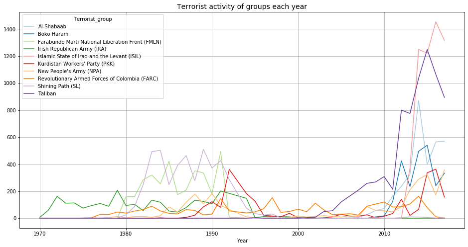

```python
fig = plt.figure()
group = data[data['Terrorist_group'] != 'Unknown']
group = group[group['Terrorist_group'].isin(group['Terrorist_group'].value_counts().index[:10])]
group = pd.crosstab(group.Year,group.Terrorist_group)
group.plot(color=sns.color_palette('Paired',10))
fig = plt.gcf()
fig.set_size_inches(16,8)
plt.title("Terrorist activity of groups each year", fontsize=14)
plt.grid(True)
plt.show()
```

#### 3. What are the most common methods of attacks chosen by terrorist groups?

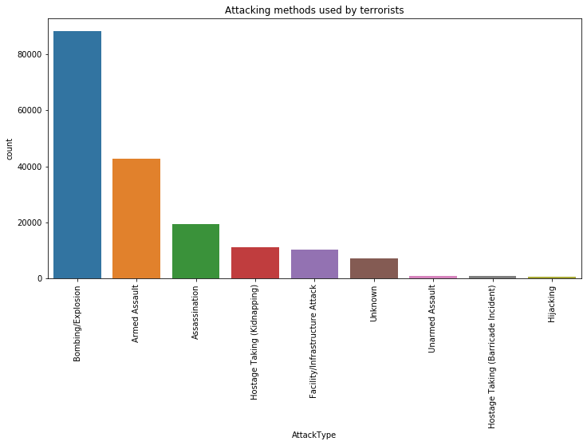

```
Bombing/Explosion                      88255
Armed Assault                          42669
Assassination                          19312
Hostage Taking (Kidnapping)            11158
Facility/Infrastructure Attack         10356
Unknown                                 7276
Unarmed Assault                         1015
Hostage Taking (Barricade Incident)      991
Hijacking                                659
Name: AttackType, dtype: int64
```

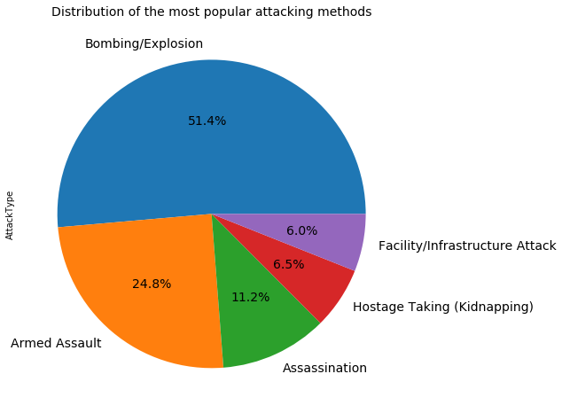

```python
series = data['AttackType'].value_counts().index

plt.subplots(figsize=(12,6))
sns.countplot('AttackType',data=data, order=series)
plt.xticks(rotation=90)
plt.title('Attacking methods used by terrorists')
plt.show()

result = data['AttackType'].value_counts()
print(result)
result = result[:5]

result.plot(kind='pie', subplots=True, figsize=(8, 8), fontsize=14, autopct = '%1.1f%%')
plt.title('Distribution of the most popular attacking methods', fontsize=14)
plt.show()
```

And what weapon do they usually use?

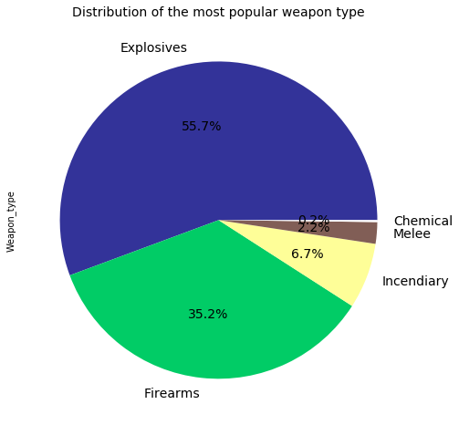

```python
series = data[data['Weapon_type'] != 'Unknown']
series = series['Weapon_type'].value_counts()
series = series[:5]

fig = plt.figure(figsize=(16,8))
series.plot(kind='pie', subplots=True, fontsize=14, autopct = '%1.1f%%', colormap = 'terrain')
plt.title('Distribution of the most popular weapon type', fontsize=14)
plt.show()
```

#### 4. What is the most common way of attack in the various regions?

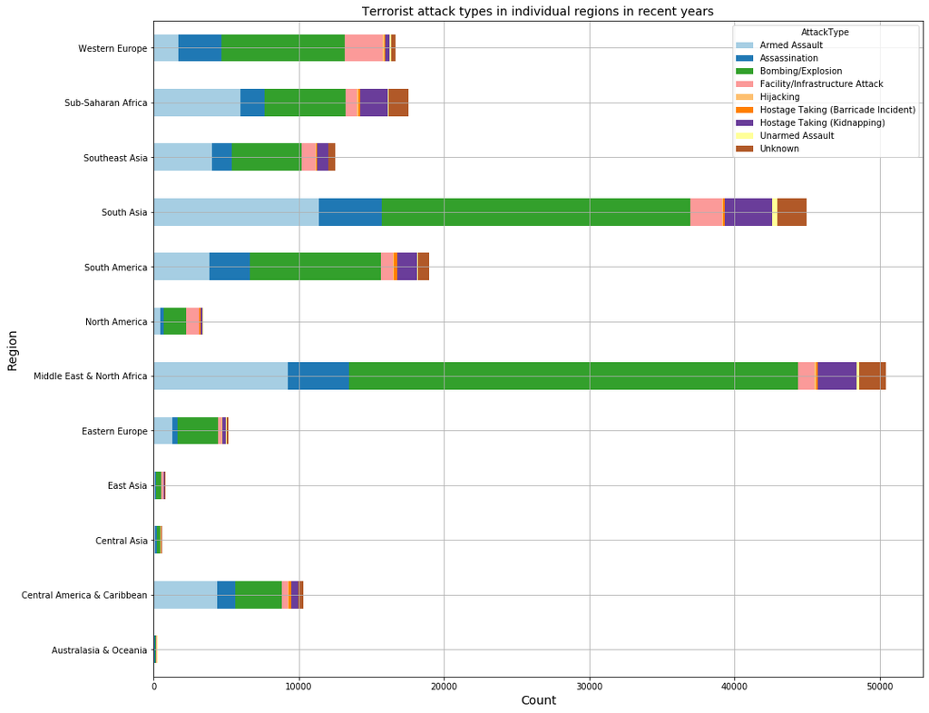

```python
fig = plt.figure()
result = pd.crosstab(data.Region,data.AttackType)
result.plot.barh(stacked=True, colormap = 'Paired')
fig=plt.gcf()
fig.set_size_inches(16,14)
plt.xlabel('Count', fontsize=14)
plt.ylabel('Region', fontsize=14)
plt.title('Terrorist attack types in individual regions in recent years', fontsize=14)
plt.grid(True)
plt.show()
```

#### 5. What attack methods are chosen by terrorist groups?

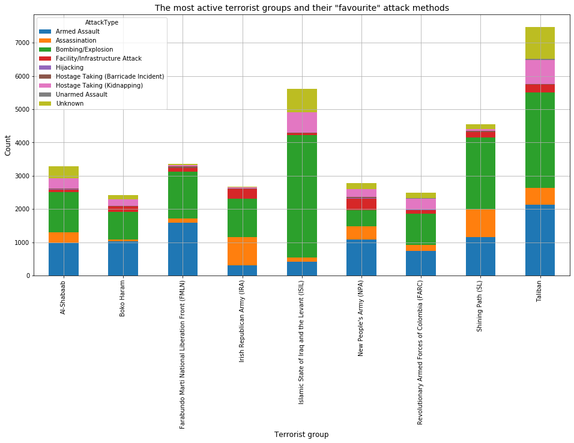

```python
series = data.loc[:,['Terrorist_group', 'AttackType']]
groups = series['Terrorist_group'].value_counts().index[:10]
#print(groups)

series = series[series['Terrorist_group'].isin(groups)]
series = series[series['Terrorist_group'] != 'Unknown']
#print(series)

tab = pd.crosstab(series.Terrorist_group, series.AttackType)
#print(tab)

fig = plt.figure()
tab.plot.bar(stacked=True)
fig=plt.gcf()
fig.set_size_inches(16,8)
plt.xlabel('Terrorist group', fontsize=12)
plt.ylabel('Count', fontsize=12)
plt.xticks(rotation=90)
plt.title('The most active terrorist groups and their "favourite" attack methods', fontsize=14)
plt.grid(True)
plt.show()
```

**The most active terrorist groups and their "favourite" attack method:**

```python
series = data.loc[:,['Terrorist_group', 'AttackType']] #Selecting a sub-table of interesting columns
scolumn = series.loc[:,"Terrorist_group"] #Get one column with the group name
values_counts = scolumn.value_counts()
lvalues = values_counts.keys().tolist() #Get list of values
lcounts = values_counts.tolist() #Get list of counters


noRow = data.shape[0] #Number of rows in whole data

minimal_count = 2000 #Choosing the most active groups

print("Terrorist group | The most often attack method | Count\n")

for i in range(0,len(lvalues)):  #View terrorist group

    if lcounts[i] < minimal_count: continue #Irrelevant group

    gName = lvalues[i]

    if gName == 'Unknown': continue #Irrelevant group

    #Creating dictionary of attacks for terrorist group
    loc_dictio = dict()
    for j in range(0,noRow):  #View attacks for the terrorist group
        loc_gname = series.iat[j,0]
        if (loc_gname==gName):
            loc_attack_name = str(series.iat[j,1])
            if (loc_attack_name) not in loc_dictio:
                loc_dictio[loc_attack_name] = 1 #New attack
            else:
                loc_dictio[loc_attack_name] += 1 #Incrementing given attack

    maxCount = 0
    maxName = ''
    for k, v in loc_dictio.items():
        if v > maxCount:
            maxName = k
            maxCount = v

    print(gName,"|",maxName,"|",str(maxCount)) #Display information: terrorist group with its the most often attack method and count
```

```
Terrorist group | The most often attack method | Count

Taliban | Bombing/Explosion | 2866
Islamic State of Iraq and the Levant (ISIL) | Bombing/Explosion | 3679
Shining Path (SL) | Bombing/Explosion | 2161
Farabundo Marti National Liberation Front (FMLN) | Armed Assault | 1594
Al-Shabaab | Bombing/Explosion | 1217
New People's Army (NPA) | Armed Assault | 1088
Irish Republican Army (IRA) | Bombing/Explosion | 1155
Revolutionary Armed Forces of Colombia (FARC) | Bombing/Explosion | 924
Boko Haram | Armed Assault | 1024
Kurdistan Workers' Party (PKK) | Armed Assault | 901
Basque Fatherland and Freedom (ETA) | Bombing/Explosion | 1205
```

```
This is the end of my analysis. Now I would like to thank you a lot for taking a look at my work. I believe that you have also learned something new :)
It's my first data analysis done in Python and I hope not the last.
```